# Лабораторная работа №8

Настройка сетевых сервисов. DHCP

Ко Антон Геннадьевич

antonkosakh@gmail.com

Российский университет дружбы народов

2026-09-04

# Информация

## Докладчик

- Ко Антон Геннадьевич
- студент
- Российский университет дружбы народов им. П. Лумумбы
- 1132221551@rudn.ru
- https://SenDerMen04.github.io/ru/

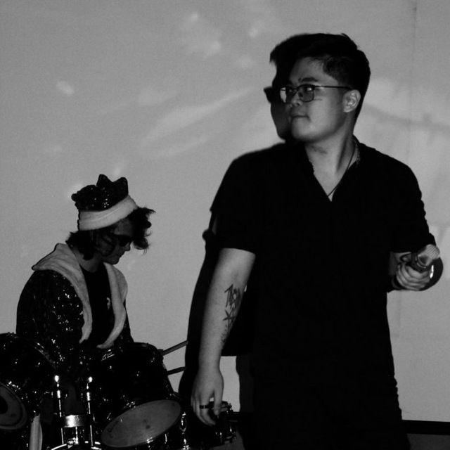

## Цель работы

Приобрести практические навыки по настройке динамического распределения IP-адресов посредством протокола DHCP (Dynamic Host Configuration Protocol) в локальной сети.

## Выполнение работы

В логическую рабочую область проекта добавим сервер dns и подключим его к коммутатору `msk-donskaya-agko-sw-3` через порт Fa0/2 (рис. #fig:002):

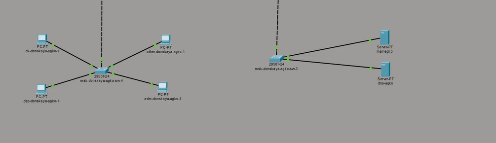

Добавление сервера dns в логическую рабочую область проекта и подключение его к коммутатору msk-donskaya-agko-sw-3

Далее активируем порт при помощи соответствующих команд на коммутаторе (рис. #fig:003):

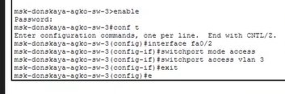

Активация порта на коммутаторе

Настроим конфигурацию сервера: адрес шлюза — 10.128.0.1, адрес сервера — 10.128.0.5, маска 255.255.255.0 (рис. #fig:004):

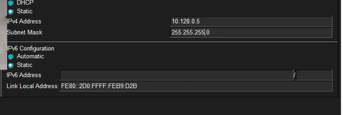

Настройка конфигурации сервера (адрес шлюза, адрес сервера, маска)

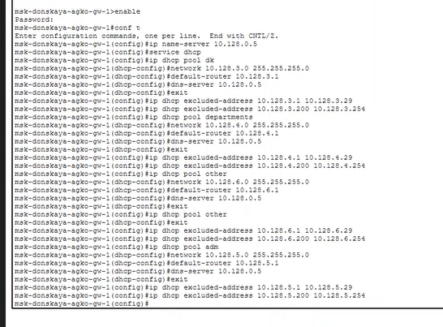

Настройка DHCP-сервиса на маршрутизаторе

Заменим статическое распределение адресов на динамическое на оконечных устройствах (рис. #fig:007):

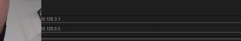

Замена статического распределения адресов на динамическое на оконечных устройствах

Затем проверим, какие адреса выделяются оконечным устройствам (рис. #fig:008):

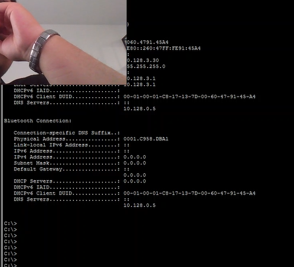

Проверка адресов, выделяемых оконечным устройствам

Проверим доступность устройств из разных подсетей (рис. #fig:009):

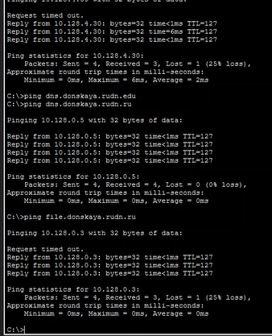

Проверка доступности устройств из разных подсетей

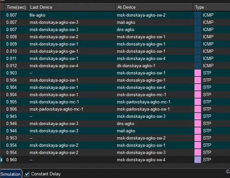

## Вывод

В ходе выполнения лабораторной работы мы приобрели практические навыки по настройке динамического распределения IP-адресов посредством протокола DHCP (Dynamic Host Configuration Protocol) в локальной сети.